# General linear regression: course evaluations

M6 ICA2

# Introduction

This is adapted from Lab 6 in Duke’s Introduction to Data Science course.

We will analyze what goes into course evaluations and how certain variables effect the overall score.

To get started, load the packages `tidyverse` and `broom`.

```r
library(MASS)
library(tidyverse)
library(broom)
```

# Data

The data were gathered from end of semester student evaluations for a large sample of professors from the University of Texas at Austin. In addition, six students rated the professors’ physical appearance. Each row in `evals` contains a different course and the columns represent variables about the courses and professors.

Use `read.csv()` to read in the data and save it as an object named `evals`. The data is available on D2L.

```r
evals <- read.csv("evals-mod.csv")
```

Below is a description of the variables in the data-set.

| **Variable** | **Description** |
| --- | --- |
| score | Average professor evaluation score: (1) very unsatisfactory - (5) excellent |
| rank | Rank of professor: teaching, tenure track, tenure |
| ethnicity | Ethnicity of professor: not minority, minority |
| gender | Gender of professor: female, male |
| language | Language of school where professor received education: English or non-English |
| age | Age of professor |
| cls_perc_eval | Percent of students in class who completed evaluation |
| cls_did_eval | Number of students in class who completed evaluation |
| cls_students | Total number of students in class |
| cls_level | Class level: lower, upper |
| cls_profs | Number of professors teaching sections in course in sample: single, multiple |
| cls_credits | Number of credits of class: one credit (lab, PE, etc.), multi credit |
| bty_f1lower | Beauty rating of professor from lower level female: (1) lowest - (10) highest |
| bty_f1upper | Beauty rating of professor from upper level female: (1) lowest - (10) highest |
| bty_f2upper | Beauty rating of professor from upper level female: (1) lowest - (10) highest |
| bty_m1lower | Beauty rating of professor from lower level male: (1) lowest - (10) highest |
| bty_m1upper | Beauty rating of professor from upper level male: (1) lowest - (10) highest |
| bty_m2upper | Beauty rating of professor from upper level male: (1) lowest - (10) highest |

Before you get started, add the `avg_bty` variable.

```r
evals <- evals %>%
  rowwise() %>%
  mutate(avg_bty = mean(bty_f1lower:bty_m2upper)) %>%
  ungroup()
evals
```

| score | rank | ethnicity | gender | language | age | cls_perc_eval | cls_did_eval | cls_students | cls_level | cls_profs | cls_credits | bty_f1lower | bty_f1upper | bty_f2upper | bty_m1lower | bty_m1upper | bty_m2upper | avg_bty |
| --- | --- | --- | --- | --- | --- | --- | --- | --- | --- | --- | --- | --- | --- | --- | --- | --- | --- | --- |
| 4.7 | tenure track | minority | female | english | 36 | 55.81395 | 24 | 43 | upper | single | multi credit | 5 | 7 | 6 | 2 | 4 | 6 | 5.5 |
| 4.1 | tenure track | minority | female | english | 36 | 68.80000 | 86 | 125 | upper | single | multi credit | 5 | 7 | 6 | 2 | 4 | 6 | 5.5 |
| 3.9 | tenure track | minority | female | english | 36 | 60.80000 | 76 | 125 | upper | single | multi credit | 5 | 7 | 6 | 2 | 4 | 6 | 5.5 |
| 4.8 | tenure track | minority | female | english | 36 | 62.60163 | 77 | 123 | upper | single | multi credit | 5 | 7 | 6 | 2 | 4 | 6 | 5.5 |
| 4.6 | tenured | not minority | male | english | 59 | 85.00000 | 17 | 20 | upper | multiple | multi credit | 4 | 4 | 2 | 2 | 3 | 3 | 3.5 |
| 4.3 | tenured | not minority | male | english | 59 | 87.50000 | 35 | 40 | upper | multiple | multi credit | 4 | 4 | 2 | 2 | 3 | 3 | 3.5 |
| 2.8 | tenured | not minority | male | english | 59 | 88.63636 | 39 | 44 | upper | multiple | multi credit | 4 | 4 | 2 | 2 | 3 | 3 | 3.5 |
| 4.1 | tenured | not minority | male | english | 51 | 100.00000 | 55 | 55 | upper | single | multi credit | 5 | 2 | 5 | 2 | 3 | 3 | 4.0 |
| 3.4 | tenured | not minority | male | english | 51 | 56.92308 | 111 | 195 | upper | single | multi credit | 5 | 2 | 5 | 2 | 3 | 3 | 4.0 |
| 4.5 | tenured | not minority | female | english | 40 | 86.95652 | 40 | 46 | upper | single | multi credit | 2 | 5 | 4 | 3 | 3 | 2 | 2.0 |

[output cut: 453 more lines]

# Part 1

## Categorical predictors

#### Task 1

Fit a linear model with `score` as the response and `language` as a single predictor. Write out the estimated model.

```r
mod.fit <- lm(score ~ language, data = evals )

mod.fit %>%
  broom::tidy()
```

| term | estimate | std.error | statistic | p.value |
| --- | --- | --- | --- | --- |
| (Intercept) | 4.189655 | 0.02595108 | 161.444342 | 0.00000000 |
| languagenon-english | -0.246798 | 0.10552781 | -2.338701 | 0.01977733 |

#### Task 2

What is the baseline level of the previous model? Interpret the meaning of coefficient $b_1$.

#### Task 3

Based on Task 1, what is the equation of the line for professors who received education at English speaking schools? What about for those who received education at non-English speaking schools?

#### Task 4

Create a scatter plot of `score` versus `rank` with `ggplot()`. Use `geom_jitter()`.

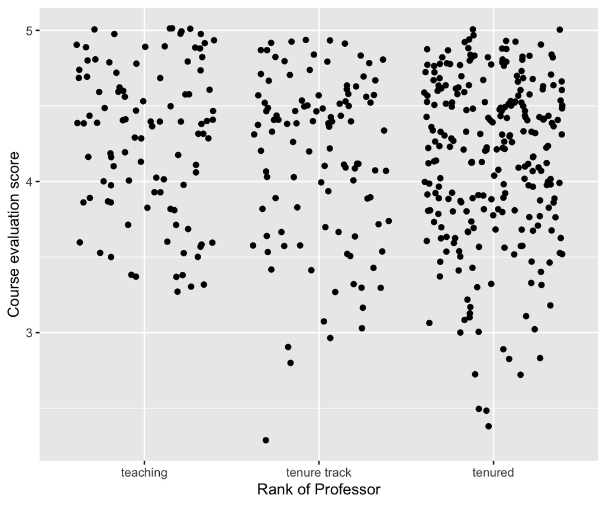

```r
ggplot(evals, aes(x= rank, y= score)) +
  geom_jitter() +
  labs(x = "Rank of Professor", y = "Course evaluation score")
```

#### Task 5

Fit a linear model with `score` as the response and `rank` as a single predictor. What is the baseline level? Write out the equation of the estimated model.

```r
mod.fit <- lm(score ~ rank, data = evals )

mod.fit %>%
  broom::tidy()
```

| term | estimate | std.error | statistic | p.value |
| --- | --- | --- | --- | --- |
| (Intercept) | 4.2843137 | 0.05365284 | 79.852504 | 1.021033e-271 |
| ranktenure track | -0.1296841 | 0.07481531 | -1.733390 | 8.369651e-02 |
| ranktenured | -0.1451833 | 0.06355455 | -2.284389 | 2.280338e-02 |

#### Task 6

Add a new variable to `evals` called `rank_new` where the baseline level is set to “tenured”. *Hint*: `rank = factor(rank)` and `relevel()`

```r
evals <- evals %>%
  mutate(rank_new = relevel(factor(rank), ref = "tenured"))
evals
```

| score | rank | ethnicity | gender | language | age | cls_perc_eval | cls_did_eval | cls_students | cls_level | cls_profs | cls_credits | bty_f1lower | bty_f1upper | bty_f2upper | bty_m1lower | bty_m1upper | bty_m2upper | avg_bty | rank_new |
| --- | --- | --- | --- | --- | --- | --- | --- | --- | --- | --- | --- | --- | --- | --- | --- | --- | --- | --- | --- |
| 4.7 | tenure track | minority | female | english | 36 | 55.81395 | 24 | 43 | upper | single | multi credit | 5 | 7 | 6 | 2 | 4 | 6 | 5.5 | tenure track |
| 4.1 | tenure track | minority | female | english | 36 | 68.80000 | 86 | 125 | upper | single | multi credit | 5 | 7 | 6 | 2 | 4 | 6 | 5.5 | tenure track |
| 3.9 | tenure track | minority | female | english | 36 | 60.80000 | 76 | 125 | upper | single | multi credit | 5 | 7 | 6 | 2 | 4 | 6 | 5.5 | tenure track |
| 4.8 | tenure track | minority | female | english | 36 | 62.60163 | 77 | 123 | upper | single | multi credit | 5 | 7 | 6 | 2 | 4 | 6 | 5.5 | tenure track |
| 4.6 | tenured | not minority | male | english | 59 | 85.00000 | 17 | 20 | upper | multiple | multi credit | 4 | 4 | 2 | 2 | 3 | 3 | 3.5 | tenured |
| 4.3 | tenured | not minority | male | english | 59 | 87.50000 | 35 | 40 | upper | multiple | multi credit | 4 | 4 | 2 | 2 | 3 | 3 | 3.5 | tenured |
| 2.8 | tenured | not minority | male | english | 59 | 88.63636 | 39 | 44 | upper | multiple | multi credit | 4 | 4 | 2 | 2 | 3 | 3 | 3.5 | tenured |
| 4.1 | tenured | not minority | male | english | 51 | 100.00000 | 55 | 55 | upper | single | multi credit | 5 | 2 | 5 | 2 | 3 | 3 | 4.0 | tenured |
| 3.4 | tenured | not minority | male | english | 51 | 56.92308 | 111 | 195 | upper | single | multi credit | 5 | 2 | 5 | 2 | 3 | 3 | 4.0 | tenured |
| 4.5 | tenured | not minority | female | english | 40 | 86.95652 | 40 | 46 | upper | single | multi credit | 2 | 5 | 4 | 3 | 3 | 2 | 2.0 | tenured |

[output cut: 453 more lines]

#### Task 7

Fit a linear model with `score` as the response and `rank_new` as a single predictor. Is the baseline now different from the baseline in Task 5?

```r
mod.fit <- lm(score ~ rank_new, data = evals )

mod.fit %>%
  broom::tidy()
```

| term | estimate | std.error | statistic | p.value |
| --- | --- | --- | --- | --- |
| (Intercept) | 4.13913043 | 0.03406689 | 121.5000796 | 0.00000000 |
| rank_newteaching | 0.14518329 | 0.06355455 | 2.2843887 | 0.02280338 |
| rank_newtenure track | 0.01549919 | 0.06228368 | 0.2488484 | 0.80358911 |

**Now the intercept corresponds to Tenured professors, and the other rank coefficients give differences from tenured.*